# Sentiment Analysis 1

Dory Munoko

12/21/2021

The aim of this project is to build a sentiment analysis model which will allow us to categorize words based on their sentiments, that is whether they are positive, negative and also the magnitude of it.

Developing our Sentiment Analysis Model in R We will carry out sentiment analysis with R in this project. The dataset that we will use will be provided by the R package ‘janeaustenR’.

```r
library(tidytext)
library(janeaustenr)
library(dplyr)
library(stringr)
library(tidyr)
```

```r
library(ggplot2)
library(reshape2)
library(wordcloud)
sentiments
```

# A tibble: 6,786 x 2

```r
get_sentiments("bing")
```

# A tibble: 6,786 x 2

word sentiment  
1 2-faces negative 2 abnormal negative 3 abolish negative 4 abominable negative 5 abominably negative 6 abominate negative 7 abomination negative 8 abort negative 9 aborted negative 10 aborts negative # … with 6,776 more rows

Performing Sentiment Analysis with the Inner Join The janeaustenr package- Provides us with the textual data in the form of books authored by the novelist Jane Austen. Tidytext- allows us to perform efficient text analysis on our data. unnest_tokens() function- to convert the text of our books into a tidy format.

```r
tidy <- austen_books() %>%
        group_by(book) %>%
        mutate(linenumber = row_number(),
        chapter = cumsum(str_detect(text, regex("^chapter [\\divxlc]",
                          ignore_case = TRUE)))) %>%
ungroup() %>%
     unnest_tokens(word, text)
```

```r
positive_sent <- get_sentiments("bing") %>%
                  filter(sentiment == "positive")

tidy %>%
  filter(book == "Emma") %>%
  semi_join(positive_sent) %>%
  count(word, sort = TRUE)
```

# A tibble: 668 x 2

word n 1 well 401 2 good 359 3 great 264 4 like 200 5 better 173 6 enough 129 7 happy 125 8 love 117 9 pleasure 115 10 right 92 # … with 658 more rows Use spread() function to segregate our data into separate columns of positive and negative sentiments. Use the mutate() function to calculate the total sentiment (the difference between positive and negative sentiment).

```r
bing <- get_sentiments("bing")
        Emma_sentiment <- tidy %>%
        inner_join(bing) %>%
        count(book = "Emma" , index = linenumber %/% 80, sentiment) %>%
        spread(sentiment, n, fill = 0) %>%
        mutate(sentiment = positive - negative)
```

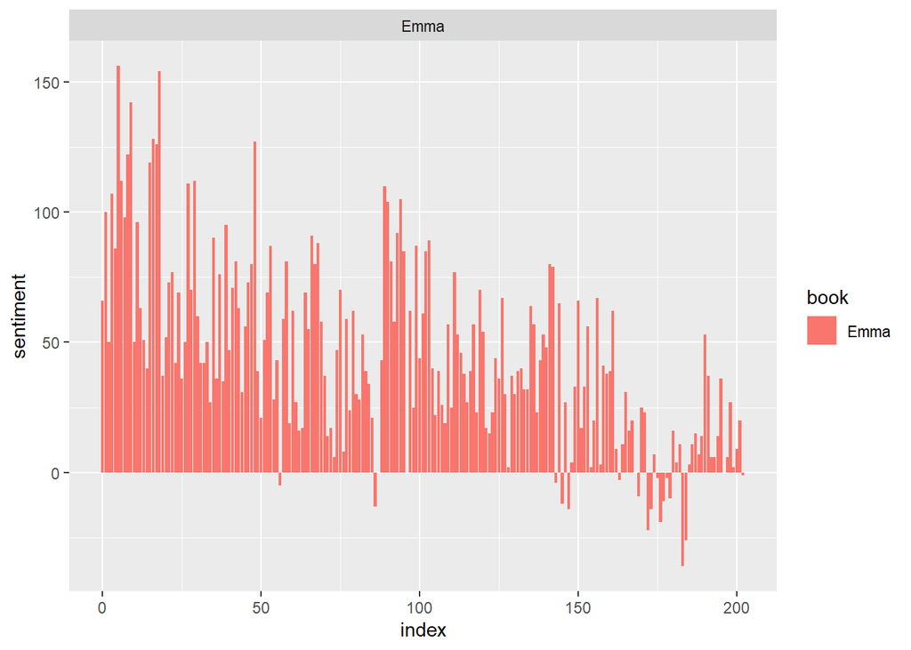

```r
ggplot(Emma_sentiment, aes(index, sentiment, fill = book)) +
       geom_bar(stat = "identity", show.legend = TRUE) +
       facet_wrap(~book, ncol = 2, scales = "free_x")
```

```r
count_words <- tidy %>%
               inner_join(bing) %>%
               count(word, sentiment, sort = TRUE)
               head(count_words)
```

# A tibble: 6 x 3

word sentiment n 1 miss negative 1855 2 well positive 1523 3 good positive 1380 4 great positive 981 5 like positive 725 6 better positive 639

Visualization of our sentiment score.

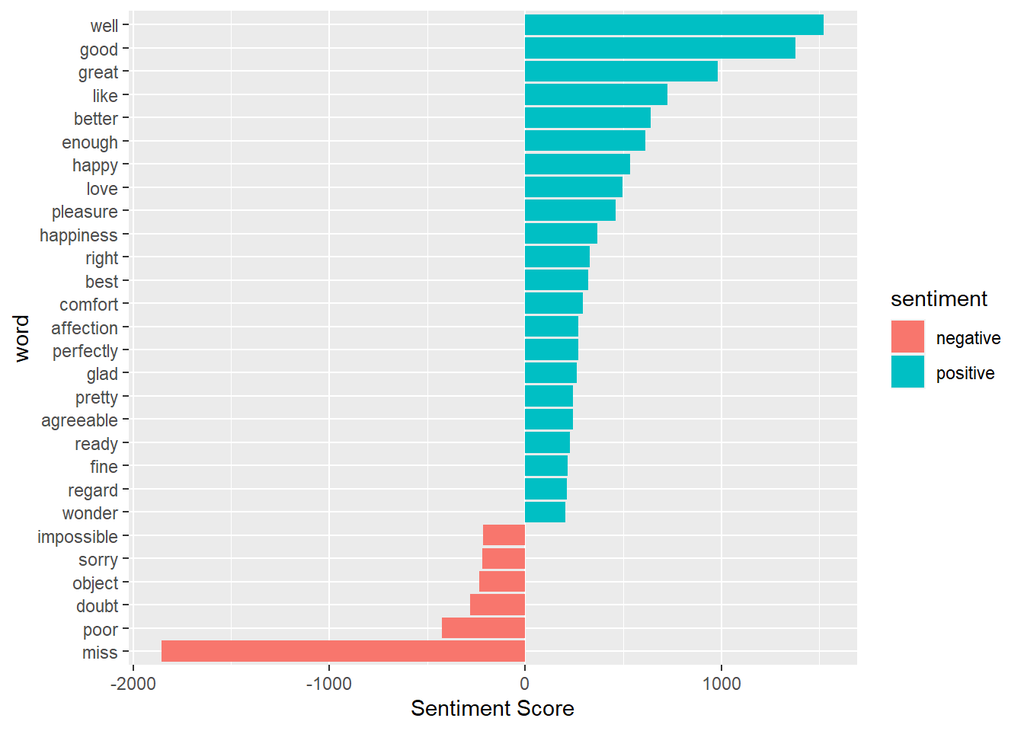

```r
count_words %>%
         filter(n > 200) %>%
         mutate(n = ifelse(sentiment == "negative", -n, n)) %>%
         mutate(word = reorder(word, n)) %>%
ggplot(aes(word, n, fill = sentiment))+
         geom_col() +
         coord_flip() +
         labs(y = "Sentiment Score")
```

Use the comparision.cloud() function to plot both negative and positive words in a single wordcloud.

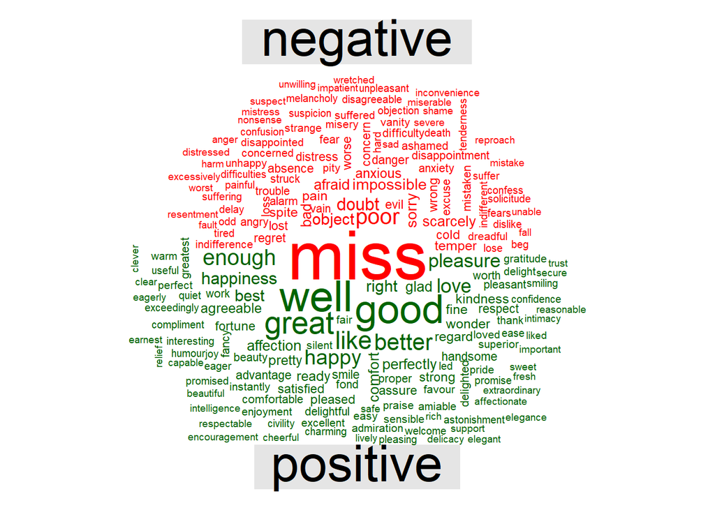

```r
tidy %>%
   inner_join(bing) %>%
   count(word, sentiment, sort = TRUE) %>%
   acast(word ~ sentiment, value.var = "n", fill = 0) %>%
   comparison.cloud(colors = c("red", "dark green"),
          max.words = 200)
```